# Econometría Aplicada con R

## Uso de vectores en condicionales

- Nota que el argumento de entrada solo es un número (escalar) ¿Qué sucede si tratamos de ejecutar el condicional sobre un vector?

```r
edad <- c(5, 15, 21, 67, 40, 98)
probar_edad(edad)
```

- En `R` podemos vectorizar los condicionales usando la función `ifelse()`.
- En lugar de escribir una línea de código para cada comparación, podemos usar una sola llamada a esta función, que se aplicará a cada elemento de un vector.
- Esta función tiene la siguiente estructura:

```r
ifelse(vector_entrada, valor_SI_TRUE, valor_SI_FALSE)
```

- En nuestro ejemplo sobre las edades:

```r
edad <- c(5, 15, 21, 67, 40, 98)
ifelse( edad >= 18, "Adulto", "Niño")
```

## Ejemplo: Función `ifelse()`

Podemos usar la función `ifelse()` para saber si los número en un vector son pares o nones:

```r
num <- 1:10

ifelse(num %% 2 == 0, "Par", "Non")
```

Esta función puede ser muy útil para recodificar datos:

- Dicotómica a texto
- Texto a dicotómica

```r
num <- c(0, 1 , 1, 0 , 0 ,1, 0)
genero <- ifelse(num == 0, "Hombre", "Mujer")
genero
```

```r
num2 <- c("Hombre", "Mujer", "Mujer", "Hombre")
genero2 <- ifelse(num2 == "Hombre", 0 , 1)
genero2
```

## Estructuras de control: `for`

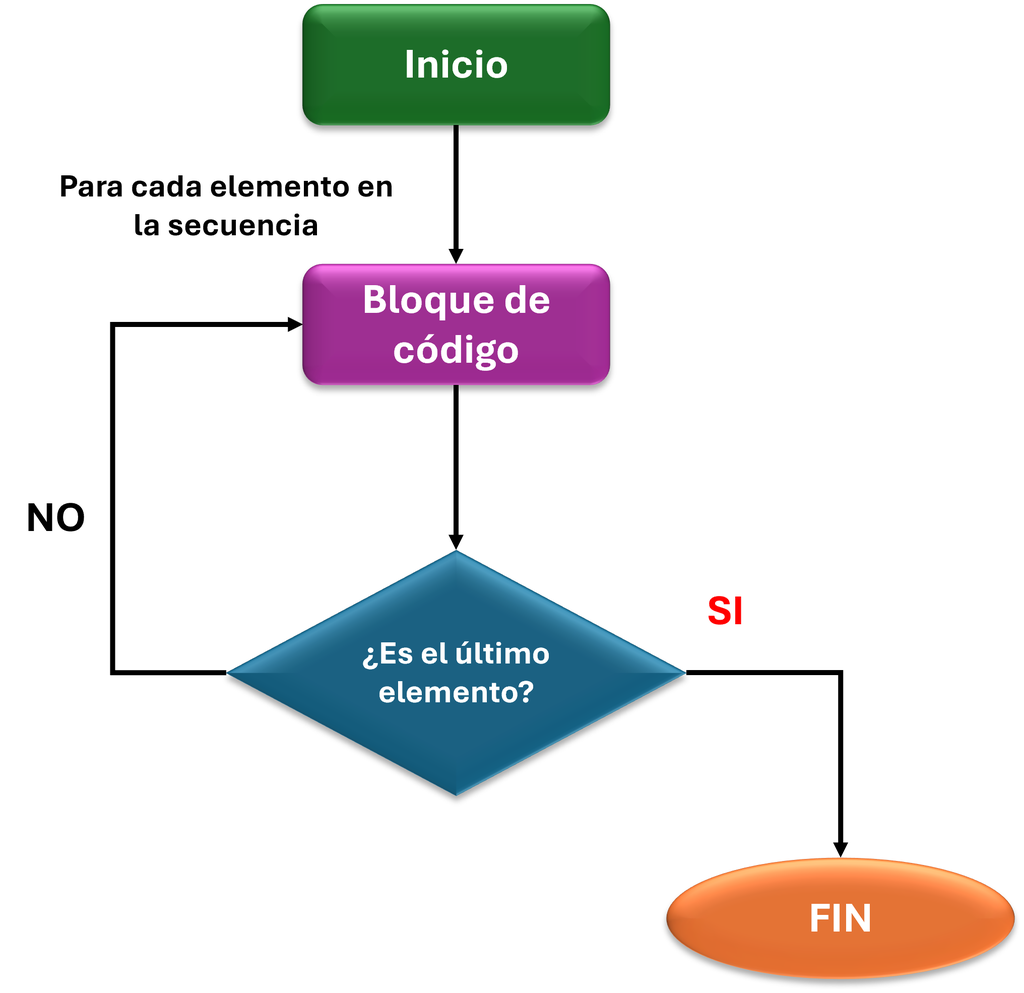

## Estructuras de control: `for`

Un `for` loop nos permite **repetir una operación** un número determinado de veces.

**Sintáxis básica:**

```r
for (variable in secuencia) {
  # operación
}
```

**Ejemplo:**

```r
# Calcular el logaritmo del PIB per cápita de 5 países
pib <- c(8500, 12300, 45000, 3200, 67000)

for (i in pib) {
  print(log(i))
}
```

**Nota**

En R los loops son menos comunes que en otros lenguajes porque muchas operaciones están **vectorizadas** por defecto. Por ejemplo, `log(pib)` produce el mismo resultado que el loop anterior.

# Fin del segundo bloque 🗣

# Bloque 3: Flujo de trabajo para el análisis de datos

## Diagrama de flujo de trabajo ideal

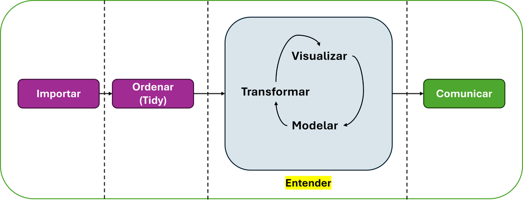

Fuente: [R 4 Data Science](https://r4ds.had.co.nz/introduction.html)

## Proyectos y directorios de trabajo

Cuando empiezas a programar para ti mismo:

- Crea un folder dedicado a tu proyecto.
- Inicia un nuevo proyecto de `R`: `File>New Project >Existing Directory`
- Se creará un archivo con extensión `.RProj`.

Ventajas:

- El directorio de trabajo se fijará **automáticamente**.
- Automáticamente se recupera el historial de acciones y los objetos contenidos en el proyecto.
- Es más fácil de reproducir los resultados (path relativo vs. absoluta)

```r
getwd()
setwd()
```

## Estructura de directorios del proyecto

Cada proyecto tiene su propia lógica pero yo recomiendo usar la siguiente estructura de directorios:

```
nombre_proyecto

├── README.md
├── codigo
│ ├── 1_preparacion_datos.Rmd
│ ├── 2_manipulacion_datos.Rmd
│ ├── 3_analisis_datos.Rmd
│ ├── 3_estadistica_descriptiva.Rmd
│ ├── 4_visualizacion.Rmd
│ └── lib_func.R
├── datos
│ ├── originales
│ └── procesados
├── figuras
└── nombre_proyecto.Rproj
```

- Nunca guardes los datos manipulados sobre el archivo original.
- Siempre incluye un `README.md` para saber que es lo que hace este proyecto.

## Creación de estructura de directorios de trabajo

Podemos generar la estructura de carpetas directamente desde `R`:

```r
###########################################################
# Esta función genera una estructura de directorios y
# archivos .Rmd en blanco para comenzar nuestro proyecto.
#
# El único argumento de entrada es el path.
###########################################################

plantilla_proyecto <- function(path) {
  # Verificar si el directorio base existe
  if (!dir.exists(path)) {
    stop(paste("El directorio", path, "no existe."))
  }

  # Cambiar el directorio de trabajo
  setwd(path)

  # Nombre del proyecto
  nombre_proyecto <- "Proyecto_1"

  # Crear carpeta principal del proyecto si no existe
  if (!dir.exists(nombre_proyecto)) {
    dir.create(nombre_proyecto)
  }

  # Definir estructura de carpetas (sin acentos)
  nombre_subcarpetas <- file.path(nombre_proyecto, c(
    "datos", "codigo", "figuras",    # Carpetas principales
    "datos/original", "datos/procesados" # Subcarpetas
  ))

  # Crear todas las carpetas de manera eficiente
  lapply(nombre_subcarpetas, dir.create, recursive = TRUE)

  # Crear los archivos dentro de la carpeta "codigo"
  carpeta_codigo <- file.path(nombre_proyecto, "codigo")

  # Verificar si la carpeta "codigo" existe antes de crear los archivos
  if (!dir.exists(carpeta_codigo)) {
    stop("La carpeta 'codigo' no existe.")
  }

  # Definir nombres de los archivos (sin acentos)
  file_names <- c(
    "1_preparacion_datos",  # Preparación de datos
    "2_manipulacion_datos", # Combinación de datos
    "3_est_descriptiva",    # Descriptivos
    "3_analisis_datos",     # Análisis
    "4_visualizacion"       # Visualización
  )

  # Crear las rutas completas para los archivos dentro de "codigo"
  file_paths <- file.path(carpeta_codigo, paste0(file_names, ".Rmd"))

  # Crear los archivos
  file.create(file_paths)

  # Crear un archivo adicional para funciones auxiliares
  file.create(file.path(carpeta_codigo, "funciones.R"))

  message("Estructura del proyecto creada exitosamente.")
}
```

# Librerías y paquetes en `R`

## Paquetes en `R`

Existen más de 20 mil funciones escritas por usuarios de `R` que están contenidas en *paquetes* (`packages`).

- Hasta ahora solo hemos utilizado funciones que vienen incluidas de forma nativa en `R base`.
  - Los paquetes que han sido revisados de alguna forma por los usuarios de la comunidad de `R` se almacenan en el [Comprehensive R Archive Network (CRAN)](https://cran.r-project.org/web/packages/).
  - Al momento de elaborar estas diapositivas la biblioteca del CRAN cuenta con 23,867 paquetes disponibles.

## Paquetes en `R`

- Un paquete en `R` es como un foco 💡

```r
# Para usar un paquete primero debemos instalarlo
install.packages("package_name")
  # install.packages(package_name)

# Si queremos usar el paquete debemos invocarlo
library(package_name)
```

## Uso del paquete `dplyr`

El paquete `dplyr` utiliza una **gramática** para la manipulación de datos a partir de un conjunto consistente de **verbos** (funciones):

| Verbo (función) | Descripción |
| --- | --- |
| `filter()` | Seleccionar **filas** que cumplan una o varias condiciones lógicas |
| `select()` | Seleccionar o descartar **columnas** |
| `rename()` | Cambiar el nombre de una **columna** |
| `mutate()` | Transformar valores o crear una nueva **columna** |
| `group_by()` | Agrupar datos en una o más columnas |
| `arrange()` | Ordenar las filas de acuerdo al valor de las variables |
| `summarize()` | Reduce un grupo de datos a una sola **fila** |

## Uso de la función `filter()`

Selecciona **filas** en un `dataframe`

- Uso:

```r
filter(nombre_objeto, condición)
```

- Anteriormente usamos la sintáxis de `R base` para hacer algo similar:

```r
imdb[imdb$duration_minutes == 132, "name"] # R Base
df <- filter(imdb, duration_minutes == 132) # dplyr
```

## Uso de la función `select()`

Seleccionar o descartar **columnas** en un `dataframe`.

- Uso:

```r
select(df, col1, col2)  # Selecciona columnas 1-2
select(df, -col3)  # Selecciona todas las columnas menos col3
```

- Uso de **funciones de selección** especiales:

```r
select(df, contains("col"))  # Seleccionar columnas que contienen "col"
```

- Comparativa:

```r
df[,c("nombre", "edad")]  # R Base
select(df, nombre, edad)  # Tidyverse
```

## Uso de la función `mutate()`

Transforma valores o crea columnas nuevas.

- Uso:

```r
mutate(df, colum_name = operación)
```

Añadir una nueva columna:

```r
df$nueva_var <- var + 20  # R base
df <- mutate(df, nueva_var = var + 20) # Tidyverse
```

## Uso de la función `rename()`

La usamos para renombrar columnas existentes.

- Uso:

```r
rename(df, new_col_name = old_col_name)
```

- Ejemplo:

```r
imdb$duration_minutes <- imdb$duracion_min # R Base
imdb <- rename(imdb, duracion_min = duration_minutes)  # dplyr
```

## Uso de la función `group_by()`

- Es útil cuando queremos realizar operaciones en algunos grupos dentro de un conjunto de datos.
- Sintáxis básica:

```r
library(dplyr)

df_agrupado <- df %>%
                group_by(grupo1, grupo2, ...)
```

- Donde:
  - `df` es un conjunto de datos rectangular.
  - `grupo1, grupo2,...` las columnas a partir de las cuales se quieren agrupar los datos.

## Uso de la función `summarize()`

- Esta función se utiliza para generar un resumen de los datos.
- Permite calcular estadísticas descriptivas (promedios, sumas, max, min, etc.) sobre un conjunto de datos **agrupado**.
- Sintáxis básica de uso:

```r
resumen <- df %>%
            group_by(categoria) %>%
            summarize(estadistica = funcion(df_columna))
```

- Donde:
  - `df` es un conjunto de datos agrupado con la función `group_by()`.
  - `estadistica`: El nombre de la columna que contendrá el resumen de los datos.
  - `funcion()`: Cálculo que deseas aplicar (p.ej. `mean()`, `sum()`, `max()`, etc.)

## Ejemplo de uso de funciones `group_by()` y `summarize()`

```r
# Datos de ejemplo
datos <- data.frame(
  categoria = c("A", "A", "B", "B", "C"),
  valor = c(10, 20, 30, 40, 50)
)

# Calcular resumen sin agrupar
resumen_general <- datos %>%
  summarize(promedio_valor = mean(valor))

# Calcular resumen agrupado
resumen_por_categoria <- datos %>%
  group_by(categoria) %>%
  summarize(
    promedio_valor = mean(valor),
    desvest_valor = sd(valor)
  )
```

## El **operador pipe** `|>` o `%>%`

- El símbolo `%>%` o `|>` (entonces o después) es un componente que encadena todas las operaciones de manipulación de datos.
- Ventajas:
  - Nuestro código tiene una gramática más amigable.
  - No es necesario anidar las llamadas a las funciones.
  - Es más sencillo eliminar/agregar operaciones en nuestro flujo de trabajo sin detener el código.

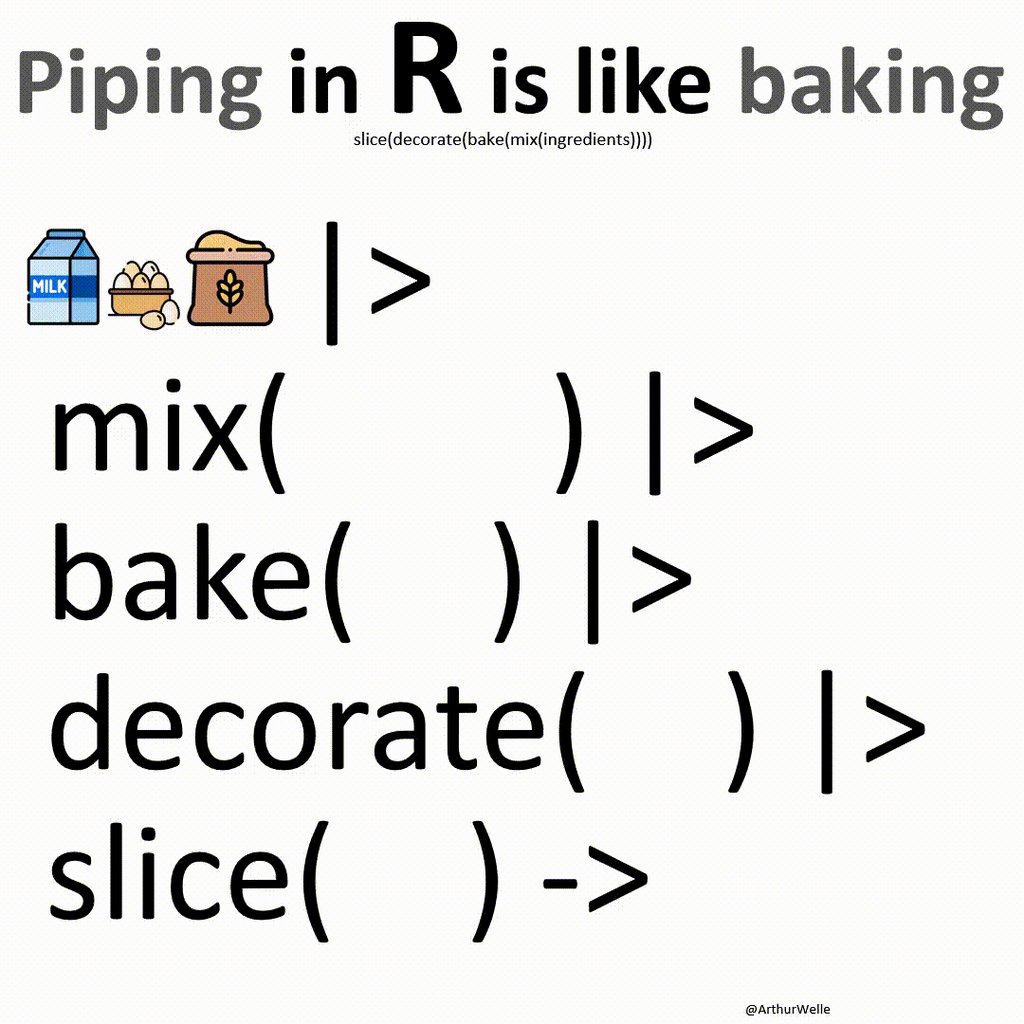

- Notas:

- `df` solo se menciona una vez al principio (seleccionar y guardar resultados de operaciones).
- El código termina una vez que dejan de existir `|>` o `%>%`.

## Ejercicio

Utiliza la base de datos IMDB y realiza las siguientes tareas utilizando los verbos de la librería `dplyr()`:

1. Filtra los datos y conserva únicamente aquellas películas que duren más de 100 minutos.
2. Conserva únicamente el nombre, año, clasificación, rating y duración de las películas.
3. Crea una nueva variable dicotómica que nos permita saber si la película fue estrenada después del año 2004,
4. Renombra la columna `certificate` con la palabra `clasificación`
5. Elimina todos los `NA` en la base de datos
6. Crea un nuevo `dataframe`que contenga la estadística descriptiva del rating de las películas por cada clasificación en la muestra (promedio, máximo, mínimo y el número de películas)

# Fin de la sesión 🕺🏿